# Peer Graded Assignment: Prediction Assignment Writeup

Phuc Huy Vo

23/04/2022

## Overview

Using devices such as Jawbone Up, Nike FuelBand, and Fitbit, it’s possible to collect a large amount of data about personal activity relatively simply. With this data we can predict the manner in which participants perform a barbell lift. For this purpose, six people were asked to perform the same set of exercises correctly and incorrectly with accelerometers placed on the belt, forearm, arm, and dumbell. The result of each performance could be one of this class: Class A: exactly according to the specification Class B: throwing the elbows to the front Class C: lifting the dumbbell only halfway Class D: lowering the dumbbell only halfway Class E: throwing the hips to the front

The goal of this project of the Coursera Practical Machine Learning course is to predict the manner in which people did the exercise, starting from the data collected by accelerometers.

## Cleaning and preparing the data

The first step is to load the data.

```r
library(caret)
training <- read.csv("training.csv", na.strings=c("NA","#DIV/0!", ""))
testing <- read.csv("testing.csv", na.strings=c("NA","#DIV/0!", ""))
```

Then it’s useful to see the structure of the dataset (I hide the rusult to save space):

```r
str(training)
```

It can be noted that there are non valid values, like the abreviation “NA” (for not available), the string “#DIV/01”, and the empty value for num values. All these values can be considered “null”" values:

```r
training <- read.csv("training.csv", na.strings=c("NA","#DIV/0!", ""))
testing <- read.csv("testing.csv", na.strings=c("NA","#DIV/0!", ""))
```

Looking at the structure of the dataset we noticed some useless columns. These column are removed:

```r
training <- training[,-c(1,2,3,4,5,6,7)]
testing <- testing[,-c(1,2,3,4,5,6,7)]
```

We remove other not useful column, like those with small variance

```r
nsv <- nearZeroVar(training)
training <- training[, -nsv]
testing <- testing[, -nsv]
```

At last we remove column with more than 75% of null values

```r
smallNA <- colSums(is.na(training)) < (nrow(training) * 0.75)
training <- training[, smallNA]
testing <- testing[, smallNA]
```

```r
dim(training)
```

```
## [1] 19622    53
```

## Prediction Model Selection

First we split the train dataset in two parts. The first one will be use to build the predictive models (train dataset), and the second one to check the accuracy of the model (validation dataset).

```r
set.seed(50318) # For reproducibile purpose
inTrain <- createDataPartition(training$classe, p=0.70, list=F)
trainData <- training[inTrain, ]
validationData <- training[-inTrain, ]
```

The model with the best accuracy will be chose and use in last to predict the required outcomes of the test dataset.

To choose the best model, we compare the most used ones. For each of them we build the predictive model on the subtrain data set, then predict on the validation data set and finally create the “Confusion matrix” to measure the precision of the model.

The first model we consider it’s the Decision Tree.

```r
model_rpart <- train(classe ~ ., data=trainData, method='rpart')
pred_rpart <- predict(model_rpart, newdata=validationData)
cm_rpart <- confusionMatrix(pred_rpart, validationData$classe)
print(cm_rpart)
```

```
## Confusion Matrix and Statistics
##
##           Reference
## Prediction    A    B    C    D    E
##          A 1531  481  477  432  151
##          B   31  365   31  169  155
##          C  110  293  518  363  293
##          D    0    0    0    0    0
##          E    2    0    0    0  483
##
## Overall Statistics
##
##                Accuracy : 0.4923
##                  95% CI : (0.4794, 0.5051)
##     No Information Rate : 0.2845
##     P-Value [Acc > NIR] : < 2.2e-16
##
##                   Kappa : 0.3363
##  Mcnemar's Test P-Value : NA
##
## Statistics by Class:
##
##                      Class: A Class: B Class: C Class: D Class: E
## Sensitivity            0.9146  0.32046  0.50487   0.0000  0.44640
## Specificity            0.6341  0.91867  0.78205   1.0000  0.99958
## Pos Pred Value         0.4984  0.48602  0.32847      NaN  0.99588
## Neg Pred Value         0.9492  0.84924  0.88208   0.8362  0.88907
## Prevalence             0.2845  0.19354  0.17434   0.1638  0.18386
## Detection Rate         0.2602  0.06202  0.08802   0.0000  0.08207
## Detection Prevalence   0.5220  0.12761  0.26797   0.0000  0.08241
## Balanced Accuracy      0.7743  0.61956  0.64346   0.5000  0.72299
```

The “accuracy” is not so good: it’s only 0.4923. Following it’s showed the classification tree:

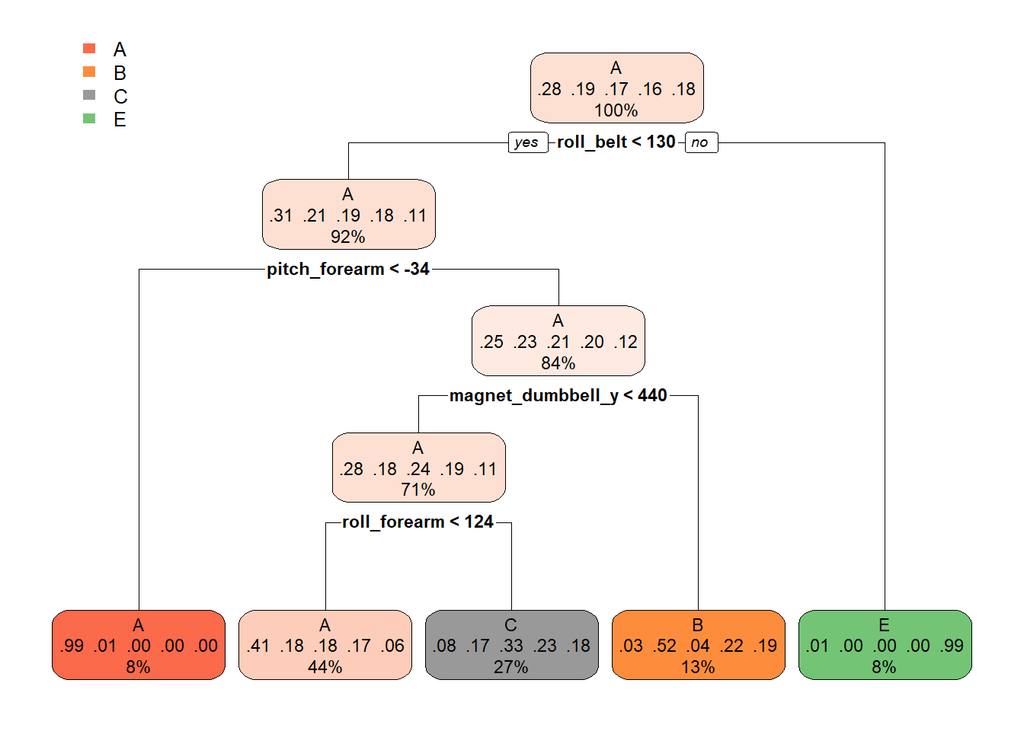

```r
library(rpart.plot)
rpart.plot(model_rpart$finalModel)
```

The second model is “boosted trees”:

```r
model_gbm <- train(classe ~ ., data=trainData, method='gbm')
pred_gbm <- predict(model_gbm, newdata=validationData)
```

```r
cm_gbm <- confusionMatrix(pred_gbm, validationData$classe)
print(cm_gbm)
```

```
## Confusion Matrix and Statistics
##
##           Reference
## Prediction    A    B    C    D    E
##          A 1652   40    0    0    1
##          B   13 1053   34    1   14
##          C    5   43  973   31   10
##          D    3    3   16  923   12
##          E    1    0    3    9 1045
##
## Overall Statistics
##
##                Accuracy : 0.9594
##                  95% CI : (0.954, 0.9643)
##     No Information Rate : 0.2845
##     P-Value [Acc > NIR] : < 2.2e-16
##
##                   Kappa : 0.9486
##  Mcnemar's Test P-Value : 1.03e-06
##
## Statistics by Class:
##
##                      Class: A Class: B Class: C Class: D Class: E
## Sensitivity            0.9869   0.9245   0.9483   0.9575   0.9658
## Specificity            0.9903   0.9869   0.9817   0.9931   0.9973
## Pos Pred Value         0.9758   0.9444   0.9162   0.9645   0.9877
## Neg Pred Value         0.9948   0.9820   0.9890   0.9917   0.9923
## Prevalence             0.2845   0.1935   0.1743   0.1638   0.1839
## Detection Rate         0.2807   0.1789   0.1653   0.1568   0.1776
## Detection Prevalence   0.2877   0.1895   0.1805   0.1626   0.1798
## Balanced Accuracy      0.9886   0.9557   0.9650   0.9753   0.9815
```

The accuracy is a lot better: 0.9594. The third is linear discriminant analysis:

```r
model_lda <- train(classe ~ ., data=trainData, method='lda')
pred_lda <- predict(model_lda, newdata=validationData)
```

```r
cm_lda <- confusionMatrix(pred_lda, validationData$classe)
print(cm_lda)
```

```
## Confusion Matrix and Statistics
##
##           Reference
## Prediction    A    B    C    D    E
##          A 1393  182  127   63   32
##          B   27  709   79   35  180
##          C  124  136  652   99   99
##          D  122   45  143  726  115
##          E    8   67   25   41  656
##
## Overall Statistics
##
##                Accuracy : 0.7028
##                  95% CI : (0.6909, 0.7145)
##     No Information Rate : 0.2845
##     P-Value [Acc > NIR] : < 2.2e-16
##
##                   Kappa : 0.6235
##  Mcnemar's Test P-Value : < 2.2e-16
##
## Statistics by Class:
##
##                      Class: A Class: B Class: C Class: D Class: E
## Sensitivity            0.8321   0.6225   0.6355   0.7531   0.6063
## Specificity            0.9041   0.9324   0.9057   0.9136   0.9706
## Pos Pred Value         0.7752   0.6883   0.5874   0.6308   0.8231
## Neg Pred Value         0.9313   0.9114   0.9217   0.9497   0.9163
## Prevalence             0.2845   0.1935   0.1743   0.1638   0.1839
## Detection Rate         0.2367   0.1205   0.1108   0.1234   0.1115
## Detection Prevalence   0.3054   0.1750   0.1886   0.1956   0.1354
## Balanced Accuracy      0.8681   0.7774   0.7706   0.8334   0.7885
```

The accuracy has a value between the two previus methods: 0.7028.  
The last is the random forest:

```r
model_rf <- train(classe ~ ., data=trainData, method='rf')
pred_rf <- predict(model_rf, newdata=validationData)
```

```r
cm_rf <- confusionMatrix(pred_rf, validationData$classe)
print(cm_rf)
```

```
## Confusion Matrix and Statistics
##
##           Reference
## Prediction    A    B    C    D    E
##          A 1673   11    0    0    0
##          B    0 1123    4    0    0
##          C    1    4 1018   10    0
##          D    0    0    4  953    0
##          E    0    1    0    1 1082
##
## Overall Statistics
##
##                Accuracy : 0.9939
##                  95% CI : (0.9915, 0.9957)
##     No Information Rate : 0.2845
##     P-Value [Acc > NIR] : < 2.2e-16
##
##                   Kappa : 0.9923
##  Mcnemar's Test P-Value : NA
##
## Statistics by Class:
##
##                      Class: A Class: B Class: C Class: D Class: E
## Sensitivity            0.9994   0.9860   0.9922   0.9886   1.0000
## Specificity            0.9974   0.9992   0.9969   0.9992   0.9996
## Pos Pred Value         0.9935   0.9965   0.9855   0.9958   0.9982
## Neg Pred Value         0.9998   0.9966   0.9984   0.9978   1.0000
## Prevalence             0.2845   0.1935   0.1743   0.1638   0.1839
## Detection Rate         0.2843   0.1908   0.1730   0.1619   0.1839
## Detection Prevalence   0.2862   0.1915   0.1755   0.1626   0.1842
## Balanced Accuracy      0.9984   0.9926   0.9946   0.9939   0.9998
```

The accuracy is even better than the “boosted trees”:0.9939.

## Results

The “random forest”“is the method we choose because it has the best performances.  
The expected out of sample error is 1-accuracy so it is 0,0061.  
We use it to predict outcomes of the test data set, as follows:

```r
FinalPrediction <- predict(model_rf, testing)
print(FinalPrediction)
```

```
##  [1] B A B A A E D B A A B C B A E E A B B B
## Levels: A B C D E
```